# A1.1 584678

### A1.1 Aprendizaje estadístico-automático

**1. Importa los datos del archivo “Obesidad.csv” a tu ambiente de trabajo en una Jupyter Notebook y muestra en consola un resumen, imprimiendo las primeras 10 filas de datos. Recuerda que es conveniente que el archivo “csv” y tu libreta estén en el mismo directorio.**

```python
import pandas as pd
import numpy as np
import matplotlib.pyplot as plt

data = pd.read_csv("A1.1 Obesidad.csv")
print(data.head(10))
```

```
     Sexo  Edad  Estatura  Peso FamiliarConSobrepeso ComeMuchasCalorias  \
0  Female  21.0      1.62  64.0                  yes                 no
1  Female  21.0      1.52  56.0                  yes                 no
2    Male  23.0      1.80  77.0                  yes                 no
3    Male  27.0      1.80  87.0                   no                 no
4    Male  22.0      1.78  89.8                   no                 no
5    Male  29.0      1.62  53.0                   no                yes
6  Female  23.0      1.50  55.0                  yes                yes
7    Male  22.0      1.64  53.0                   no                 no
8    Male  24.0      1.78  64.0                  yes                yes
9    Male  22.0      1.72  68.0                  yes                yes

   ComeVegetales Fumador  ConsumoDeAgua      NivelDeObesidad
0            2.0      no            2.0        Normal_Weight
1            3.0     yes            3.0        Normal_Weight
2            2.0      no            2.0        Normal_Weight
3            3.0      no            2.0   Overweight_Level_I
4            2.0      no            2.0  Overweight_Level_II
5            2.0      no            2.0        Normal_Weight
6            3.0      no            2.0        Normal_Weight
7            2.0      no            2.0        Normal_Weight
8            3.0      no            2.0        Normal_Weight
9            2.0      no            2.0        Normal_Weight
```

**2. Imprime en consola o genera un cuadro de descripción que muestre un mensaje donde indiques qué otra variable hubieras decidido medir si formaras parte del grupo de investigación, indicando claramente si la información recopilada se consideraría como cuantitativa o cualitativa.**

Agregaria a las variables si la persona consume alcohol, la cual seria una variable cualitativa, ya que representa una categoria entre si toma o no toma alcohol.

**3. Si tú fueras el líder del proyecto y quisieras realizar un estudio de inferencia, ¿qué variable de la base de datos definirías como la salida o respuesta? Aquella variable para la que te interesa encontrar asociaciones específicas. Imprime el promedio de dicha variable, si es cuantitativa, o la cantidad de personas que pertenecen a cada categoría, si es cualitativa.**

**a. Para calcular el promedio puedes usar la función “mean()” de pandas.**

**b. Para calcular la cantidad de personas que pertenecen a cada categoría puedes usar la función “value_counts()” de pandas**

```python
y = data["NivelDeObesidad"].value_counts()
y
```

```
NivelDeObesidad
Obesity_Type_I         351
Obesity_Type_III       324
Obesity_Type_II        297
Overweight_Level_I     290
Overweight_Level_II    290
Normal_Weight          287
Insufficient_Weight    272
Name: count, dtype: int64
```

**4. Genera una gráfica, exclusivamente para la población masculina o femenina (cada quién decidirá su población de interés), que muestre en el eje “Y” la variable de salida (de acuerdo a lo que definiste en el punto anterior), y en el eje “X” alguna variable cuantitativa que les llame la atención. Asegúrate de usar un valor de transparencia menor a 0.1. Recuerda la función mágica que debes agregar para que las imágenes se visualicen sin problemas en una Jupyter Notebook.**

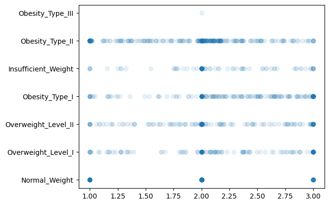

```python
data = data[data["Sexo"] == "Male"]
plt.scatter(data["ConsumoDeAgua"], data["NivelDeObesidad"], alpha=0.1)
```

**Firma de honor:** "Doy mi palabra que he realizado esta actividad con integridad académica" - Daniel Matthieu Potes Lesoinne #584678